# Measuring Ecological Intelligence on University Students

2026-02-05

## 1 Intelligence Scale

Ecological intelligence aims to develop social and environmental responsability and awareness, to think critically, to pursue cooperative learning, and to bring about behavioral change in the long-term.

Ecological intelligence should have a holistic perspective because there are seen and unseen webs among biotic and abiotic factors in the world. According to the model of Okur-Berberoglu (2020), social intelligence and economy are subsets of ecological intelligence. Social intelligence refers to social responsibilities of people in terms of sustainability. Economy should be based on sustainable development instead of explotation of environmental and human resources.

Okur-Berberoglu (2020) developed a scale for ecological intelligence. The questionnaire consists of 12 questions based on a 5 Likert scale that were scored as 1-Completely disagree, 2-Partly disagree, 3-Not sure, 4-Partly agree, and 5-Completely agree. The questions were the following.  
1. I get my full water bottle while leaving home.  
2. I wonder about increasing of cancer events in industrial areas.  
3. Degenerated environmental conditions can cause negative effect on mental health.  
4. What a pitty!, people think that technology can solve every problem, althought technology cannot produce one gram organic honey.  
5. The reflection of environmental problems can be seen at the same time, in succession, and more than one area.  
6. I try to pattern people who have positive ecologic behavior in my social life.  
7. I prefer to buy local vegetables and fruits.  
8. I believe that one of the ways of fighting with obesity is environmental education.  
9. I have remorse to know some goods I buy, are produced by explotation of human work.  
10. One of the reasons of immigration of rural people, is the job lost due to global firms.  
11. Global firms prevent local producer to have profit.  
12. People, to immigrate to another place, are cheaper laborer sources for big companies.

This scale was based on Turkey and Turkish lifestyle, as the author comment in his work this scale should the tested and understood by other researchers.

## 2 Descriptive statistics

We read the clean data. The cleaning was done in Python.

```r
data_file_path <- here::here("data", "Eco_Intel2_clean.xlsx")
dfenc <- read.xlsx(xlsxFile = data_file_path)
head(dfenc)
```

```
##       date student program      campus    sex nationality               age
## 1 45783.64       1    LAET Guadalajara  Mujer    Mexicana 21 a 22 a&#241;os
## 2 45783.64       2    LAET Guadalajara  Mujer    Mexicana 21 a 22 a&#241;os
## 3 45783.64       3    LAET Guadalajara  Mujer    Mexicana 23 a 24 a&#241;os
## 4 45783.64       4    LAET Guadalajara  Mujer    Mexicana 21 a 22 a&#241;os
## 5 45783.64       5    LAET Guadalajara Hombre    Mexicana 23 a 24 a&#241;os
## 6 45783.64       6    LAET Guadalajara  Mujer    Mexicana 21 a 22 a&#241;os
##   holis1 holis2 holis3 holis4 holis5 social1 social2 social3 social4 econ1
## 1      4      5      5      5      5       5       5       5       5     5
## 2      5      4      5      4      5       4       2       5       5     4
## 3      5      2      4      5      5       5       5       3       4     4
## 4      4      2      5      3      4       5       3       3       4     5
## 5      5      4      4      5      4       5       3       4       4     4
## 6      5      5      5      3      5       4       5       4       5     5
##   econ2 econ3 change
```

[output cut: 20 more lines]

Now we compute the indicators and its statistics.

```r
options(width=200)
dfenc <- dfenc %>%
  mutate(holis = (holis1+holis2+holis3+holis4+holis5)/5,
         social = (social1+social2+social3+social4)/4,
         econ = (econ1+econ2+econ3)/3)
psych::describe(select(dfenc,holis:econ, change))
```

```
##        vars   n mean   sd median trimmed  mad  min max range  skew kurtosis   se
## holis     1 318 4.02 0.54      4    4.04 0.59 2.00   5  3.00 -0.52     0.40 0.03
## social    2 318 3.80 0.74      4    3.85 0.74 1.25   5  3.75 -0.70     0.49 0.04
## econ      3 318 3.87 0.69      4    3.90 0.49 1.00   5  4.00 -0.57     0.60 0.04
## change    4 318 8.11 1.74      8    8.34 1.48 1.00  10  9.00 -1.43     2.91 0.10
```

Let us compare the dimensions by campus.

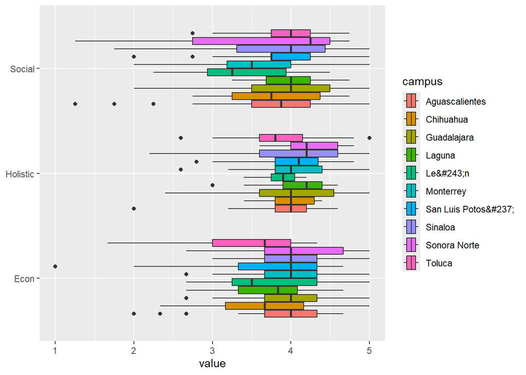

```r
stkfacts <- data.frame()
namefacts <- c("Holistic", "Social", "Econ")
tagfacts <- c("holis", "social", "econ")
for (i in 1:3) {
  dftmp <- data.frame(student = dfenc$student,
                      campus = dfenc$campus,
                      fact=rep(namefacts[i],nrow(dfenc)),
                      value = dfenc[, tagfacts[i]])
  stkfacts <- rbind(stkfacts, dftmp)
}

ggplot(stkfacts, aes(y=fact, x=value, fill=campus)) +
  geom_boxplot() +
  theme(axis.title.y = element_blank())
```

## 3 Correlation

The ecological intellegence questionnaire is composed of items that use a Likert scale, so these variables are ordinal. We compare three types of correlation: Pearson, Spearman and polychoric.

### 3.1 Pearson correlation

The Pearson correlation is used when the variables are continuous and the relationship is linear.

Let $X_1, X_2, \dots, X_p$ be a set of ordinal variables. The Pearson correlation is defined as
$$r_{ij} = \frac{\sum_{k=1}^n (X_{ik} - \bar{X}_i)(X_{jk} -
\bar{X}_j)}{\sqrt{\sum_{k=1}^n (X_{ik} - \bar{X}_i)^2 \sum_{k=1}^n
(X_{jk} - \bar{X}_j)^2}}$$
where $\bar{X}_i$ is the mean of the $i$th variable.

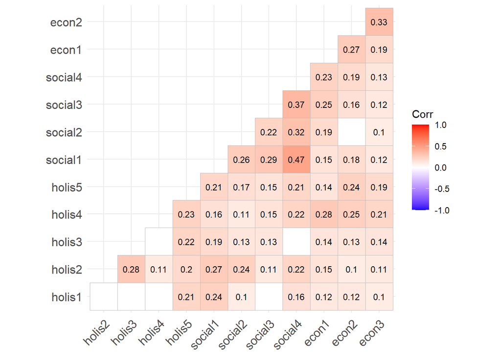

```r
corr_matrix <- cor(select(dfenc, holis1:econ3))
ggcorrplot(corr_matrix,
       type = "lower",
       lab = TRUE,
       lab_size = 3,
       insig = "blank",
       p.mat = cor_pmat(select(dfenc, holis1:econ3)),
       sig.level = 0.10)
```

### 3.2 Spearman correlation

The Spearman correlation is used when the variables are ordinal and the relationship is monotonic.

The Spearman correlation is defined as
$$r_s = \frac{\sum_{i=1}^n
(r_{x_{1i}}-\bar{r}_{x1})(r_{x_{2i}}-\bar{r}_{x2})}{\sqrt{\sum_{i=1}^n
(r_{x_{1i}}-\bar{r}_{x1})^2 \sum_{i=1}^n (r_{x_{2i}}-\bar{r}_{x2})^2}}$$
where $r_{x_{1i}}$ is the rank of the $i$th observation of the first variable, and $\bar{r}_{x1}$ is the mean of the ranks of the first variable.

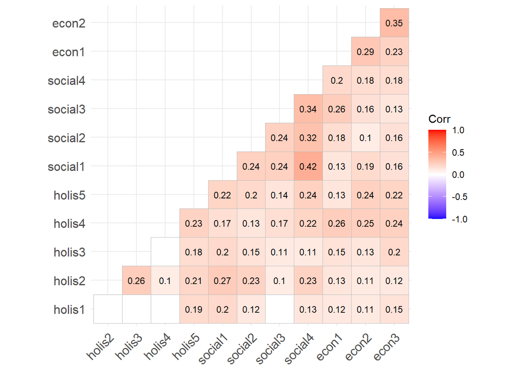

```r
spearman_corr_matrix <- cor(select(dfenc, holis1:econ3), method = "spearman")
ggcorrplot(spearman_corr_matrix,
       type = "lower",
       lab = TRUE,
       lab_size = 3,
       insig = "blank",
       p.mat = cor_pmat(select(dfenc, holis1:econ3), method = "spearman"),
       sig.level = 0.10)
```

### 3.3 Polychoric correlation

The polychoric correlation is used when the variables are ordinal, like Likert scales. It assumes that the ordinal variables are the result from discretized continuous latent variables with bivariate normal distributions. For instance, an item with five categories is conceptualized as dividing a latent variable into categories defined by thresholds on the latent variable $\xi$:
$$X = \left\{
\begin{array}{ll}
\hbox{1-Completely disagree} & \hbox{ if } \xi < \tau_1 \\
\hbox{2-Disagree} & \hbox{ if } \tau_1 \leq \xi < \tau_2 \\
\hbox{3-Neither disagree or agree} & \hbox{ if } \tau_2 \leq \xi
< \tau_3 \\
\hbox{4-Agree} & \hbox{ if } \tau_3 \leq \xi < \tau_4 \\
\hbox{5-Completely agree} & \hbox{ if } \xi \geq \tau_4 \\
\end{array}
\right.$$
where $\tau_1, \tau_2, \tau_3, \tau_4$ are the thresholds.

The first step of the algorithm is to estimate these thresholds. Each threshold can be determined based on the relative frequency of the $k$ categories. We use that observed likert scale comes from an underlying bivariate normal distribution $(X,Y)$. The likelihood for the frequency table is given by
$$L(\rho) = \prod_{i=1}^{k-1}\prod_{j=1}^{k-1}P_{ij}^{n_{ij}}$$
where $P_{ij}$ is the probability of observing the cell $(i,j)$ in the table. The probability is given by
$$P_{ij} = P(\hat\tau_{i} < X < \hat\tau_{i+1}, \hat\eta_{j} < Y
< \hat\eta_{j+1})$$
and
$$\hat\tau_k = \Phi^{-1}\left( \sum_{i=1}^k \frac{n_k}{N}\right).$$
The $\eta_1, \eta_2, \eta_3, \eta_4$ are the thresholds for the variable $Y$.

The $\rho$ that maximizes the likelihood function $L(\rho)$ is the polychoric correlation.

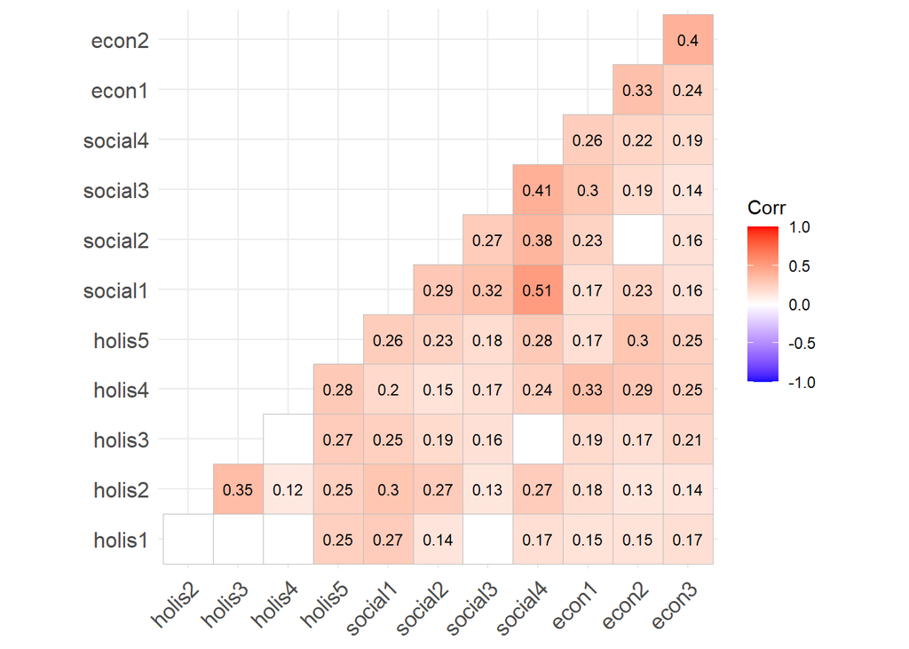

```r
library(psych)
polychoric_corr <- polychoric(select(dfenc, holis1:econ3))
polychoric_corr_matrix <- polychoric_corr$rho
ggcorrplot(polychoric_corr_matrix,
  type = "lower",
  lab = TRUE,
  lab_size = 3,
  insig = "blank",
  p.mat = cor_pmat(select(dfenc, holis1:econ3)),
  sig.level = 0.10)
```

## 4 Scale reliability

Reliability of a scale refers to the consistency and dependability of the results it produces across different instances of measurement. High reliability is crucial for ensuring that the scale provides accurate and reproducible results, making it a trustworthy tool for both clinical and research purposes.

In research reports, reliability and standard error estimations are being reported form measurement instruments used a study. In item response theory, reliability estimates do not depend on groups, and measurement errors are estimated for every different score.

Reliability is joint characteristic of a test and examinee group, not just a characteristic of a test.

### 4.1 Cronbach’s alpha

When items are used to form a scale they need to have internal consistency. The items should all measure the same thing, so they should be correlated with on another. A useful coefficient for assessing internal consistency is Cronbach’s alpha.

Ordinal aplha is conceptually equivalent to Cronbach’s alpha. The critical difference between the two is that ordinal alpha is based on polychoric correlations, while Cronbach’s alpha is based on Pearson correlations.

The formula is:
$$\alpha = \frac{k}{k-1} \left( 1-\frac{\sum s_i^2}{s_T^2} \right)$$
where $k$ is the number of items, $s_i^2$ is the variance of the ith item and $s_T^2$ is the variance of the total score formed by summing all the items. If the items are all independent, then $\alpha =0$. If the items are all identical and so perfectly correlated, then $\alpha = 1$.

```r
psych::alpha(select(dfenc, holis1:econ3))
```

```
##
## Reliability analysis
## Call: psych::alpha(x = select(dfenc, holis1:econ3))
##
##   raw_alpha std.alpha G6(smc) average_r S/N   ase mean  sd median_r
##       0.72      0.72    0.73      0.18 2.6 0.023  3.9 0.5     0.16
##
##     95% confidence boundaries
##          lower alpha upper
## Feldt     0.67  0.72  0.76
## Duhachek  0.68  0.72  0.77
##
##  Reliability if an item is dropped:
##         raw_alpha std.alpha G6(smc) average_r S/N alpha se  var.r med.r
## holis1       0.72      0.72    0.72      0.19 2.6    0.023 0.0061  0.19
## holis2       0.71      0.71    0.71      0.18 2.4    0.024 0.0067  0.17
## holis3       0.71      0.72    0.72      0.19 2.5    0.024 0.0069  0.19
## holis4       0.71      0.71    0.71      0.18 2.4    0.024 0.0070  0.17
## holis5       0.70      0.70    0.70      0.18 2.3    0.025 0.0078  0.15
## social1      0.69      0.69    0.69      0.17 2.2    0.026 0.0057  0.15
## social2      0.70      0.71    0.71      0.18 2.4    0.024 0.0068  0.16
## social3      0.70      0.70    0.71      0.18 2.4    0.025 0.0065  0.18
## social4      0.68      0.69    0.69      0.17 2.2    0.026 0.0049  0.15
## econ1        0.70      0.70    0.70      0.18 2.4    0.025 0.0074  0.16
## econ2        0.70      0.70    0.71      0.18 2.4    0.025 0.0068  0.16
## econ3        0.71      0.71    0.71      0.18 2.5    0.024 0.0071  0.18
##
##  Item statistics
##           n raw.r std.r r.cor r.drop mean   sd
## holis1  318  0.38  0.38  0.27   0.21  4.3 1.05
## holis2  318  0.47  0.47  0.39   0.32  3.4 1.08
## holis3  318  0.39  0.43  0.34   0.28  4.5 0.77
## holis4  318  0.49  0.48  0.40   0.33  3.6 1.10
## holis5  318  0.50  0.53  0.46   0.39  4.3 0.79
## social1 318  0.60  0.59  0.56   0.47  3.9 0.97
## social2 318  0.50  0.49  0.41   0.35  4.0 1.01
## social3 318  0.52  0.50  0.43   0.37  3.5 1.12
## social4 318  0.63  0.60  0.58   0.49  3.8 1.14
## econ1   318  0.52  0.52  0.45   0.39  3.9 0.99
## econ2   318  0.49  0.51  0.44   0.36  3.8 0.92
## econ3   318  0.46  0.46  0.37   0.31  3.9 1.00
##
## Non missing response frequency for each item
##            1    2    3    4    5 miss
## holis1  0.04 0.06 0.05 0.30 0.55    0
## holis2  0.06 0.11 0.36 0.30 0.17    0
## holis3  0.01 0.01 0.08 0.30 0.60    0
## holis4  0.04 0.14 0.22 0.36 0.24    0
## holis5  0.00 0.02 0.12 0.38 0.48    0
## social1 0.03 0.05 0.21 0.41 0.30    0
## social2 0.02 0.07 0.18 0.33 0.40    0
## social3 0.04 0.15 0.28 0.31 0.22    0
## social4 0.06 0.09 0.18 0.38 0.30    0
## econ1   0.02 0.08 0.19 0.42 0.30    0
## econ2   0.02 0.06 0.22 0.48 0.22    0
## econ3   0.03 0.08 0.15 0.44 0.31    0
```

```r
psych::alpha(select(dfenc, holis1:holis5))
```

```
##
## Reliability analysis
## Call: psych::alpha(x = select(dfenc, holis1:holis5))
##
##   raw_alpha std.alpha G6(smc) average_r  S/N  ase mean   sd median_r
##       0.43      0.46    0.43      0.15 0.86 0.05    4 0.54     0.16
##
##     95% confidence boundaries
##          lower alpha upper
## Feldt     0.33  0.43  0.53
## Duhachek  0.33  0.43  0.53
##
##  Reliability if an item is dropped:
##        raw_alpha std.alpha G6(smc) average_r  S/N alpha se  var.r med.r
## holis1      0.45      0.48    0.42      0.19 0.91    0.050 0.0065 0.214
## holis2      0.38      0.40    0.35      0.14 0.67    0.057 0.0072 0.141
## holis3      0.36      0.39    0.34      0.14 0.64    0.059 0.0078 0.156
## holis4      0.42      0.44    0.39      0.17 0.80    0.054 0.0108 0.208
## holis5      0.29      0.31    0.27      0.10 0.45    0.065 0.0088 0.068
##
##  Item statistics
##          n raw.r std.r r.cor r.drop mean   sd
## holis1 318  0.50  0.48  0.22   0.13  4.3 1.05
## holis2 318  0.59  0.57  0.39   0.23  3.4 1.08
## holis3 318  0.52  0.58  0.41   0.26  4.5 0.77
## holis4 318  0.57  0.52  0.29   0.19  3.6 1.10
## holis5 318  0.62  0.66  0.55   0.38  4.3 0.79
##
## Non missing response frequency for each item
##           1    2    3    4    5 miss
## holis1 0.04 0.06 0.05 0.30 0.55    0
## holis2 0.06 0.11 0.36 0.30 0.17    0
## holis3 0.01 0.01 0.08 0.30 0.60    0
## holis4 0.04 0.14 0.22 0.36 0.24    0
## holis5 0.00 0.02 0.12 0.38 0.48    0
```

```r
psych::alpha(select(dfenc, social1:social4))
```

```
##
## Reliability analysis
## Call: psych::alpha(x = select(dfenc, social1:social4))
##
##   raw_alpha std.alpha G6(smc) average_r S/N   ase mean   sd median_r
##       0.66      0.66     0.6      0.32 1.9 0.031  3.8 0.74     0.31
##
##     95% confidence boundaries
##          lower alpha upper
## Feldt     0.59  0.66  0.71
## Duhachek  0.59  0.66  0.72
##
##  Reliability if an item is dropped:
##         raw_alpha std.alpha G6(smc) average_r S/N alpha se  var.r med.r
## social1      0.57      0.57    0.47      0.30 1.3    0.042 0.0060  0.32
## social2      0.64      0.64    0.56      0.38 1.8    0.035 0.0075  0.37
## social3      0.62      0.62    0.53      0.35 1.6    0.037 0.0113  0.32
## social4      0.51      0.51    0.41      0.26 1.0    0.048 0.0014  0.26
##
##  Item statistics
##           n raw.r std.r r.cor r.drop mean   sd
## social1 318  0.70  0.72  0.58   0.47  3.9 0.97
## social2 318  0.63  0.64  0.43   0.35  4.0 1.01
## social3 318  0.69  0.67  0.48   0.39  3.5 1.12
## social4 318  0.78  0.77  0.68   0.54  3.8 1.14
##
## Non missing response frequency for each item
##            1    2    3    4    5 miss
## social1 0.03 0.05 0.21 0.41 0.30    0
## social2 0.02 0.07 0.18 0.33 0.40    0
## social3 0.04 0.15 0.28 0.31 0.22    0
## social4 0.06 0.09 0.18 0.38 0.30    0
```

```r
psych::alpha(select(dfenc, econ1:econ3))
```

```
##
## Reliability analysis
## Call: psych::alpha(x = select(dfenc, econ1:econ3))
##
##   raw_alpha std.alpha G6(smc) average_r S/N   ase mean   sd median_r
##       0.51      0.52    0.42      0.26 1.1 0.047  3.9 0.69     0.27
##
##     95% confidence boundaries
##          lower alpha upper
## Feldt     0.41  0.51  0.60
## Duhachek  0.42  0.51  0.61
##
##  Reliability if an item is dropped:
##       raw_alpha std.alpha G6(smc) average_r  S/N alpha se var.r med.r
## econ1      0.49      0.49    0.33      0.33 0.97    0.057    NA  0.33
## econ2      0.32      0.32    0.19      0.19 0.48    0.076    NA  0.19
## econ3      0.42      0.43    0.27      0.27 0.74    0.064    NA  0.27
##
##  Item statistics
##         n raw.r std.r r.cor r.drop mean   sd
## econ1 318  0.69  0.68  0.39   0.28  3.9 0.99
## econ2 318  0.73  0.75  0.54   0.39  3.8 0.92
## econ3 318  0.72  0.71  0.46   0.32  3.9 1.00
##
## Non missing response frequency for each item
##          1    2    3    4    5 miss
## econ1 0.02 0.08 0.19 0.42 0.30    0
## econ2 0.02 0.06 0.22 0.48 0.22    0
## econ3 0.03 0.08 0.15 0.44 0.31    0
```

### 4.2 Ordinal alpha

Ordinal alpha was introduced by Zumbo et al. (2007) ant it was shown to estimate reliability more accurately than Cronbach’s alpha for ordinal response scales.

McDonald (1985, p. 217) describes how one can compute coefficient alpha from a factor analysis model. For a composite score based on k items the coefficient alpha can be computed as
$$\alpha = \frac{k}{k-1} \left( \frac{k(\bar{f})^2 -
\bar{f^2}}{k(\bar{f})^2-\bar{u}^2} \right),$$
where $\bar{f}$ is the mean of the factor scores, $\bar{f^2}$ is the mean of the squared factor scores, and $\bar{u}^2$ is the mean of the squared unique variances. The analysis factor is carried out with the polychoric correlation matrix.

```r
cor_poly <- polychoric(select(dfenc, holis1:econ3))
corh_poly <- polychoric(select(dfenc, holis1:holis5))
cors_poly <- polychoric(select(dfenc, social1:social4))
core_poly <- polychoric(select(dfenc, econ1:econ3))

cat("Overall alpha =", psych::alpha(cor_poly$rho)$total$raw_alpha, "\n")
```

```
## Overall alpha = 0.7703813
```

```r
cat("Holistic alpha =", psych::alpha(corh_poly$rho)$total$raw_alpha, "\n")
```

```
## Holistic alpha = 0.516858
```

```r
cat("Econ alpha =", psych::alpha(core_poly$rho)$total$raw_alpha, "\n")
```

```
## Econ alpha = 0.5880516
```

```r
cat("Social alpha =", psych::alpha(cors_poly$rho)$total$raw_alpha, "\n")
```

```
## Social alpha = 0.6964691
```

```r
psych::alpha(cor_poly$rho)
```

```
##
## Reliability analysis
## Call: psych::alpha(x = cor_poly$rho)
##
##   raw_alpha std.alpha G6(smc) average_r S/N median_r
##       0.77      0.77    0.78      0.22 3.4     0.22
##
##     95% confidence boundaries
##       lower alpha upper
## Feldt  0.52  0.77  0.92
##
##  Reliability if an item is dropped:
##         raw_alpha std.alpha G6(smc) average_r S/N  var.r med.r
## holis1       0.77      0.77    0.78      0.23 3.4 0.0070  0.23
## holis2       0.76      0.76    0.76      0.22 3.1 0.0078  0.22
## holis3       0.76      0.76    0.77      0.22 3.2 0.0083  0.23
## holis4       0.76      0.76    0.77      0.22 3.2 0.0081  0.22
## holis5       0.75      0.75    0.76      0.21 3.0 0.0092  0.19
## social1      0.74      0.74    0.75      0.21 2.9 0.0074  0.19
## social2      0.75      0.75    0.76      0.22 3.1 0.0085  0.21
## social3      0.76      0.76    0.76      0.22 3.1 0.0079  0.23
## social4      0.74      0.74    0.75      0.21 2.9 0.0065  0.19
## econ1        0.75      0.75    0.76      0.22 3.0 0.0089  0.21
## econ2        0.75      0.75    0.76      0.22 3.0 0.0082  0.21
## econ3        0.76      0.76    0.76      0.22 3.1 0.0086  0.23
##
##  Item statistics
##            r r.cor r.drop
## holis1  0.40  0.30   0.25
## holis2  0.50  0.43   0.37
## holis3  0.48  0.40   0.35
## holis4  0.49  0.42   0.36
## holis5  0.58  0.53   0.47
## social1 0.62  0.59   0.51
## social2 0.54  0.47   0.41
## social3 0.53  0.46   0.40
## social4 0.63  0.61   0.52
## econ1   0.55  0.50   0.43
## econ2   0.55  0.49   0.43
## econ3   0.52  0.45   0.39
```

```r
psych::alpha(corh_poly$rho)
```

```
##
## Reliability analysis
## Call: psych::alpha(x = corh_poly$rho)
##
##   raw_alpha std.alpha G6(smc) average_r S/N median_r
##       0.52      0.52    0.49      0.18 1.1     0.19
##
##     95% confidence boundaries
##       lower alpha upper
## Feldt  -0.8  0.52  0.94
##
##  Reliability if an item is dropped:
##        raw_alpha std.alpha G6(smc) average_r  S/N var.r med.r
## holis1      0.54      0.54    0.49      0.23 1.17 0.010 0.261
## holis2      0.45      0.45    0.40      0.17 0.81 0.012 0.169
## holis3      0.44      0.44    0.39      0.16 0.78 0.013 0.186
## holis4      0.51      0.51    0.46      0.20 1.03 0.016 0.251
## holis5      0.35      0.35    0.31      0.12 0.54 0.014 0.082
##
##  Item statistics
##           r r.cor r.drop
## holis1 0.48  0.23   0.15
## holis2 0.60  0.44   0.31
## holis3 0.61  0.46   0.32
## holis4 0.53  0.30   0.21
## holis5 0.70  0.62   0.45
```

```r
psych::alpha(cors_poly$rho)
```

```
##
## Reliability analysis
## Call: psych::alpha(x = cors_poly$rho)
##
##   raw_alpha std.alpha G6(smc) average_r S/N median_r
##        0.7       0.7    0.64      0.36 2.3     0.35
##
##     95% confidence boundaries
##       lower alpha upper
## Feldt -0.54   0.7  0.98
##
##  Reliability if an item is dropped:
##         raw_alpha std.alpha G6(smc) average_r S/N   var.r med.r
## social1      0.62      0.62    0.53      0.35 1.6 0.00512  0.38
## social2      0.68      0.68    0.60      0.41 2.1 0.00881  0.41
## social3      0.66      0.66    0.58      0.39 1.9 0.01162  0.38
## social4      0.56      0.56    0.46      0.30 1.3 0.00055  0.29
##
##  Item statistics
##            r r.cor r.drop
## social1 0.73  0.61   0.50
## social2 0.67  0.48   0.40
## social3 0.69  0.52   0.44
## social4 0.79  0.72   0.59
```

```r
psych::alpha(core_poly$rho)
```

```
##
## Reliability analysis
## Call: psych::alpha(x = core_poly$rho)
##
##   raw_alpha std.alpha G6(smc) average_r S/N median_r
##       0.59      0.59     0.5      0.32 1.4     0.33
##
##     95% confidence boundaries
##       lower alpha upper
## Feldt -3.39  0.59  0.99
##
##  Reliability if an item is dropped:
##       raw_alpha std.alpha G6(smc) average_r  S/N var.r med.r
## econ1      0.57      0.57    0.40      0.40 1.31    NA  0.40
## econ2      0.39      0.39    0.24      0.24 0.64    NA  0.24
## econ3      0.50      0.50    0.33      0.33 0.98    NA  0.33
##
##  Item statistics
##          r r.cor r.drop
## econ1 0.71  0.44   0.34
## econ2 0.78  0.60   0.46
## econ3 0.74  0.52   0.39
```

## 5 Kaiser-Meyer-Olkin (KMO) test

The KMO test is a statistical measure to determine how suited data is for factor analysis. The test measures sampling adequacy for each variable in the model and the complete model. The statistic is a measure of the proportion of variance among variables that might be common variance.

The MSA (Measure of Sampling Adequacy) criterion is calculated and return values between 0 and 1.
$$\hbox{MSA} = \frac{\sum_{j\neq k} r_{jk}^2}{\sum_{j\neq k} r_{jk}^2 +
\sum_{j\neq k} p_{jk}^2}$$
Here $r_{jk}$ is the correlation between the variable in question and another, and $p_{jk}$ is the partial correlation. KMO values between 0.8 and 1 indicate the sampling is adequate. KMO values less than 0.6 indicate the sampling is not adequate and that remedial action should be taken. In contrast, others set this cutoff value at 0.5. A KMO value close to zero means that there are large partial correlations compared to the sum of correlations. In other words, there are widespread correlations which would be a large problem for factor analysis.

```r
cor_matrix <- cor(select(dfenc,holis1:econ3))
KMO(cor_matrix)
```

```
## Kaiser-Meyer-Olkin factor adequacy
## Call: KMO(r = cor_matrix)
## Overall MSA =  0.79
## MSA for each item =
##  holis1  holis2  holis3  holis4  holis5 social1 social2 social3 social4   econ1   econ2   econ3
##    0.70    0.76    0.74    0.81    0.81    0.77    0.83    0.81    0.77    0.80    0.78    0.79
```

```r
cat("Overall MSA =", KMO(cor_matrix)$MSA, "\n")
```

```
## Overall MSA = 0.7853931
```

```r
cor_poly <- polychoric(select(dfenc, holis1:econ3))
KMO(cor_poly$rho)
```

```
## Kaiser-Meyer-Olkin factor adequacy
## Call: KMO(r = cor_poly$rho)
## Overall MSA =  0.8
## MSA for each item =
##  holis1  holis2  holis3  holis4  holis5 social1 social2 social3 social4   econ1   econ2   econ3
##    0.69    0.79    0.75    0.80    0.82    0.79    0.86    0.83    0.79    0.79    0.80    0.82
```

```r
cat("Overall MSA =", KMO(cor_poly$rho)$MSA, "\n")
```

```
## Overall MSA = 0.7983779
```

## 6 Exploratory factor analysis

```r
M1 <- fa(cor_matrix, nfactors = 3, rotate =  "oblimin" )
print(M1)
```

```
## Factor Analysis using method =  minres
## Call: fa(r = cor_matrix, nfactors = 3, rotate = "oblimin")
## Standardized loadings (pattern matrix) based upon correlation matrix
##           MR1   MR2   MR3    h2   u2 com
## holis1   0.16  0.13  0.04 0.069 0.93 2.0
## holis2   0.13 -0.04  0.51 0.305 0.69 1.1
## holis3  -0.08  0.08  0.54 0.298 0.70 1.1
## holis4   0.12  0.43 -0.04 0.224 0.78 1.2
## holis5   0.07  0.28  0.25 0.229 0.77 2.1
## social1  0.53 -0.01  0.20 0.393 0.61 1.3
## social2  0.37 -0.03  0.19 0.214 0.79 1.5
## social3  0.43  0.11  0.01 0.233 0.77 1.1
## social4  0.80  0.02 -0.06 0.615 0.39 1.0
## econ1    0.17  0.38  0.02 0.228 0.77 1.4
## econ2   -0.02  0.62 -0.02 0.370 0.63 1.0
## econ3   -0.06  0.49  0.07 0.246 0.75 1.1
##
##                        MR1  MR2  MR3
## SS loadings           1.46 1.17 0.80
## Proportion Var        0.12 0.10 0.07
## Cumulative Var        0.12 0.22 0.29
## Proportion Explained  0.43 0.34 0.23
## Cumulative Proportion 0.43 0.77 1.00
##
##  With factor correlations of
##      MR1  MR2  MR3
## MR1 1.00 0.40 0.36
## MR2 0.40 1.00 0.34
## MR3 0.36 0.34 1.00
##
## Mean item complexity =  1.3
## Test of the hypothesis that 3 factors are sufficient.
##
## df null model =  66  with the objective function =  1.58
## df of  the model are 33  and the objective function was  0.11
##
## The root mean square of the residuals (RMSR) is  0.03
## The df corrected root mean square of the residuals is  0.04
##
## Fit based upon off diagonal values = 0.98
## Measures of factor score adequacy
##                                                    MR1  MR2  MR3
## Correlation of (regression) scores with factors   0.86 0.80 0.74
## Multiple R square of scores with factors          0.74 0.63 0.55
## Minimum correlation of possible factor scores     0.49 0.27 0.09
```

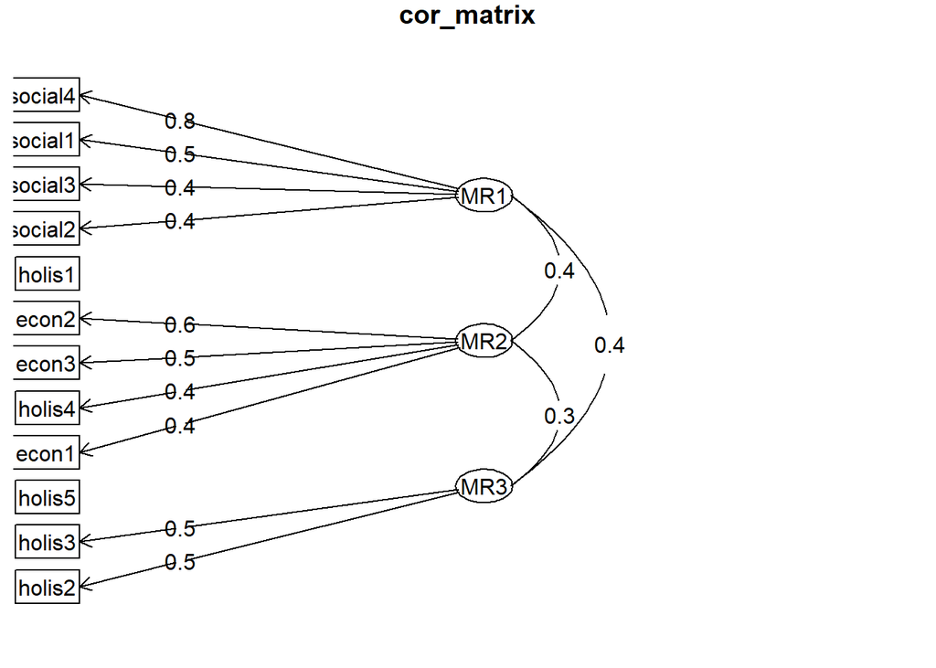

```r
fa.diagram(M1, main="cor_matrix")
```

```r
M1 <- fa(cor_poly$rho, nfactors = 3, rotate =  "oblimin" )
print(M1)
```

```
## Factor Analysis using method =  minres
## Call: fa(r = cor_poly$rho, nfactors = 3, rotate = "oblimin")
## Standardized loadings (pattern matrix) based upon correlation matrix
##           MR1   MR2   MR3    h2   u2 com
## holis1   0.16  0.17  0.02 0.086 0.91 2.0
## holis2   0.16 -0.06  0.53 0.350 0.65 1.2
## holis3  -0.07  0.08  0.63 0.404 0.60 1.1
## holis4   0.12  0.45 -0.06 0.243 0.76 1.2
## holis5   0.13  0.31  0.24 0.285 0.71 2.3
## social1  0.55  0.01  0.19 0.420 0.58 1.2
## social2  0.41  0.00  0.19 0.265 0.73 1.4
## social3  0.47  0.12 -0.02 0.272 0.73 1.1
## social4  0.82  0.01 -0.05 0.650 0.35 1.0
## econ1    0.17  0.42  0.00 0.271 0.73 1.3
## econ2   -0.02  0.68 -0.02 0.445 0.55 1.0
## econ3   -0.05  0.54  0.09 0.315 0.68 1.1
##
##                        MR1  MR2  MR3
## SS loadings           1.65 1.42 0.94
## Proportion Var        0.14 0.12 0.08
## Cumulative Var        0.14 0.26 0.33
## Proportion Explained  0.41 0.35 0.23
## Cumulative Proportion 0.41 0.77 1.00
##
##  With factor correlations of
##      MR1  MR2  MR3
## MR1 1.00 0.43 0.39
## MR2 0.43 1.00 0.38
## MR3 0.39 0.38 1.00
##
## Mean item complexity =  1.3
## Test of the hypothesis that 3 factors are sufficient.
##
## df null model =  66  with the objective function =  2.15
## df of  the model are 33  and the objective function was  0.19
##
## The root mean square of the residuals (RMSR) is  0.04
## The df corrected root mean square of the residuals is  0.05
##
## Fit based upon off diagonal values = 0.98
## Measures of factor score adequacy
##                                                    MR1  MR2  MR3
## Correlation of (regression) scores with factors   0.88 0.83 0.78
## Multiple R square of scores with factors          0.78 0.70 0.61
## Minimum correlation of possible factor scores     0.55 0.39 0.22
```

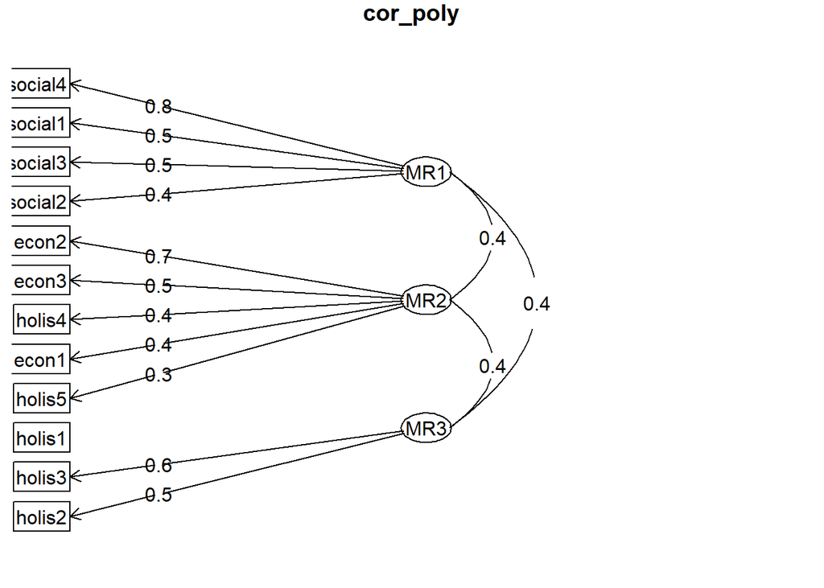

```r
fa.diagram(M1, main="cor_poly")
```

## 7 Confirmatory factor analysis

### 7.1 Maximum Likelihood

Let us estimate the model with Maximum Likelihood.

```r
dfencc <- dfenc
colnames(dfencc) <- c("date", "student", "programa", "campus", "sex",
                      "nationality", "age", "Item1", "Item2", "Item3",
                      "Item4", "Item5", "Item6", "Item7", "Item8",
                      "Item9", "Item10", "Item11", "Item12", "change",
                      "argument", "holis", "social", "econ")
dfitems <- select(dfencc, Item1:Item12)
mla <- 'holistic =~ Item1 + Item2 + Item3 + Item4 + Item5
        social =~ Item6 + Item7 + Item8 + Item9
        econ =~ Item10 + Item11 + Item12 '
fit_ml <- cfa(mla, data=dfitems, std.lv=TRUE)
summary(fit_ml, fit.measures=TRUE, standardized=TRUE)
```

```
## lavaan 0.6-19 ended normally after 18 iterations
##
##   Estimator                                         ML
##   Optimization method                           NLMINB
##   Number of model parameters                        27
##
##   Number of observations                           318
##
## Model Test User Model:
##
##   Test statistic                                76.706
##   Degrees of freedom                                51
##   P-value (Chi-square)                           0.011
##
## Model Test Baseline Model:
##
##   Test statistic                               502.192
##   Degrees of freedom                                66
##   P-value                                        0.000
##
## User Model versus Baseline Model:
##
##   Comparative Fit Index (CFI)                    0.941
##   Tucker-Lewis Index (TLI)                       0.924
##
## Loglikelihood and Information Criteria:
##
##   Loglikelihood user model (H0)              -5152.346
##   Loglikelihood unrestricted model (H1)      -5113.993
##
##   Akaike (AIC)                               10358.692
##   Bayesian (BIC)                             10460.267
##   Sample-size adjusted Bayesian (SABIC)      10374.629
##
## Root Mean Square Error of Approximation:
##
##   RMSEA                                          0.040
##   90 Percent confidence interval - lower         0.019
##   90 Percent confidence interval - upper         0.057
##   P-value H_0: RMSEA <= 0.050                    0.818
```

[output cut: 40 more lines]

```
##    .Item1             1.013    0.084   12.083    0.000    1.013    0.922
##    .Item2             0.983    0.086   11.403    0.000    0.983    0.843
##    .Item3             0.521    0.045   11.699    0.000    0.521    0.875
##    .Item4             0.991    0.089   11.106    0.000    0.991    0.814
##    .Item5             0.465    0.045   10.318    0.000    0.465    0.749
##    .Item6             0.551    0.061    9.112    0.000    0.551    0.589
##    .Item7             0.821    0.072   11.423    0.000    0.821    0.801
##    .Item8             0.944    0.085   11.049    0.000    0.944    0.755
##    .Item9             0.629    0.084    7.473    0.000    0.629    0.489
##    .Item10            0.742    0.073   10.157    0.000    0.742    0.762
##    .Item11            0.566    0.066    8.572    0.000    0.566    0.665
##    .Item12            0.760    0.075   10.194    0.000    0.760    0.764
##     holistic          1.000                               1.000    1.000
##     social            1.000                               1.000    1.000
##     econ              1.000                               1.000    1.000
```

```r
# Check modification indices to identify potential model improvements
modindices(fit_ml, sort = TRUE, minimum.value = 10)
```

```
##      lhs op   rhs     mi   epc sepc.lv sepc.all sepc.nox
## 66 Item2 ~~ Item3 10.763 0.147   0.147    0.205    0.205
```

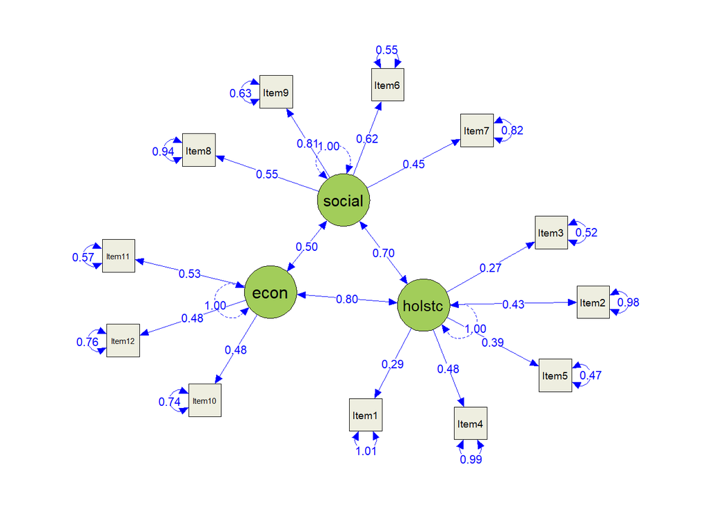

```r
library(semPlot)

semPaths(fit_ml, "path", "est", layout="spring", edge.color="blue",
         nCharNodes=6, edge.label.cex=.8, color = list(
              lat = "darkolivegreen3",
              man = "ivory2"))
```

### 7.2 Diagonally Weighted Least Squares

Now let us use the diagonally weighted least square (DWLS).

```r
dfencc <- dfenc
colnames(dfencc) <- c("date", "student", "programa", "campus", "sex",
                      "nationality", "age", "Item1", "Item2", "Item3",
                      "Item4", "Item5", "Item6", "Item7", "Item8",
                      "Item9", "Item10", "Item11", "Item12", "change",
                      "argument", "holis", "social", "econ")
dfitems <- select(dfencc, Item1:Item12)
mla <- 'holistic =~ NA*Item1 + Item2 + Item3 + Item4 + Item5
        social =~ NA*Item6 + Item7 + Item8 + Item9
        econ =~ NA*Item10 + Item11 + Item12
        holistic ~~ 1*holistic
        social ~~ 1*social
        econ ~~ 1*econ'
fit_dwls <- cfa(mla, data=dfitems, estimator="DWLS")
summary(fit_dwls, fit.measures=TRUE, standardized=TRUE)
```

```
## lavaan 0.6-19 ended normally after 26 iterations
##
##   Estimator                                       DWLS
##   Optimization method                           NLMINB
##   Number of model parameters                        27
##
##   Number of observations                           318
##
## Model Test User Model:
##
##   Test statistic                                43.647
##   Degrees of freedom                                51
##   P-value (Chi-square)                           0.758
##
## Model Test Baseline Model:
##
##   Test statistic                               638.240
##   Degrees of freedom                                66
##   P-value                                        0.000
##
## User Model versus Baseline Model:
##
##   Comparative Fit Index (CFI)                    1.000
##   Tucker-Lewis Index (TLI)                       1.017
##
## Root Mean Square Error of Approximation:
##
##   RMSEA                                          0.000
##   90 Percent confidence interval - lower         0.000
##   90 Percent confidence interval - upper         0.026
##   P-value H_0: RMSEA <= 0.050                    1.000
##   P-value H_0: RMSEA >= 0.080                    0.000
##
## Standardized Root Mean Square Residual:
##
##   SRMR                                           0.047
##
## Parameter Estimates:
##
##   Standard errors                             Standard
```

[output cut: 31 more lines]

```
##     holistic          1.000                               1.000    1.000
##     social            1.000                               1.000    1.000
##     econ              1.000                               1.000    1.000
##    .Item1             1.024    0.127    8.033    0.000    1.024    0.929
##    .Item2             0.984    0.095   10.378    0.000    0.984    0.841
##    .Item3             0.529    0.080    6.600    0.000    0.529    0.886
##    .Item4             1.007    0.096   10.468    0.000    1.007    0.825
##    .Item5             0.480    0.066    7.269    0.000    0.480    0.770
##    .Item6             0.554    0.108    5.134    0.000    0.554    0.590
##    .Item7             0.809    0.095    8.515    0.000    0.809    0.788
##    .Item8             0.946    0.102    9.303    0.000    0.946    0.754
##    .Item9             0.682    0.146    4.671    0.000    0.682    0.528
##    .Item10            0.691    0.106    6.523    0.000    0.691    0.707
##    .Item11            0.612    0.096    6.369    0.000    0.612    0.716
##    .Item12            0.794    0.102    7.824    0.000    0.794    0.796
```

```r
# Check modification indices to identify potential model improvements
modindices(fit_dwls, sort = TRUE, minimum.value = 10)
```

```
## [1] lhs      op       rhs      mi       epc      sepc.lv  sepc.all sepc.nox
## <0 rows> (o 0- extensión row.names)
```

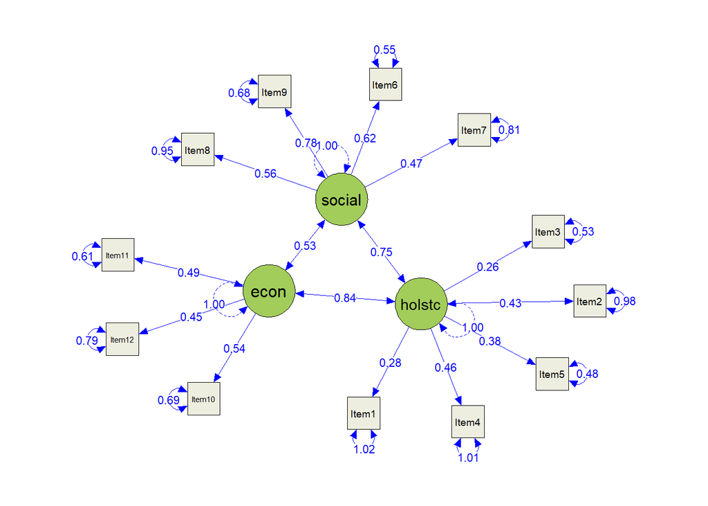

```r
library(semPlot)

# "est" estimated model parameters
# "std" The variance of both observed and latent variables is set to 1
# "std.all" Same as "std"
# "std.lv" Only the variance of latent variables is set to 1
semPaths(fit_dwls, "path", "est", layout="spring", edge.color="blue",
         nCharNodes=6, edge.label.cex=.8, color = list(
              lat = "darkolivegreen3",
              man = "ivory2"))
```

## 8 Multiple linear regression

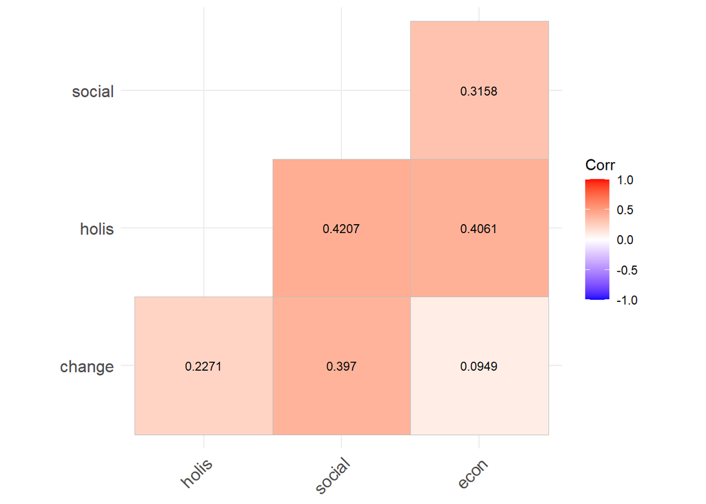

```r
p.mat <- cor_pmat(select(dfenc,change, holis:econ))
ggcorrplot(cor(select(dfenc,change, holis:econ)),
           type="lower",
           lab=TRUE,
           lab_size=3,
           insig="blank",
           p.mat=p.mat,
           digits=4,
           sig.level=0.10)
```

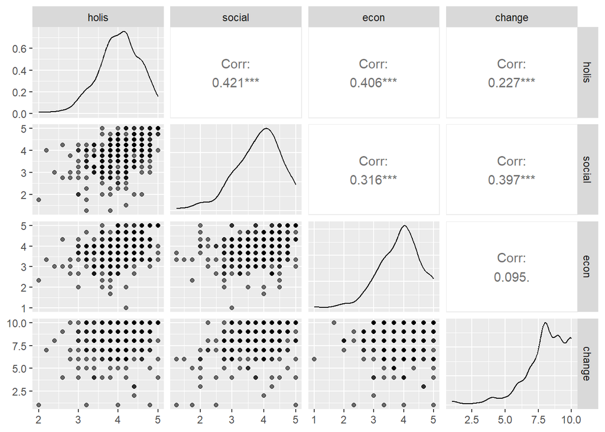

```r
ggpairs(select(dfenc,holis:econ, change), aes(alpha=0.1))
```

```r
dfencr <- dfenc
dfencr$campus <- ifelse(dfencr$campus %in% c("León", "Chihuahua"), "Otro", dfencr$campus)
model <- lm(change ~ campus + program + sex + holis + social + econ, data=dfencr)
summary(model)
```

```
##
## Call:
## lm(formula = change ~ campus + program + sex + holis + social +
##     econ, data = dfencr)
##
## Residuals:
##     Min      1Q  Median      3Q     Max
## -7.8458 -0.7071  0.1733  0.9853  3.1180
##
## Coefficients:
##                            Estimate Std. Error t value Pr(>|t|)
## (Intercept)                  4.0176     0.8064   4.982 1.06e-06 ***
## campusGuadalajara            0.4315     0.3473   1.242   0.2151
## campusLaguna                -0.6771     0.5637  -1.201   0.2306
## campusLe&#243;n             -0.4554     0.6506  -0.700   0.4845
## campusMonterrey              0.8685     0.3953   2.197   0.0288 *
## campusOtro                   0.3761     0.6805   0.553   0.5808
## campusSan Luis Potos&#237;   0.6392     0.4072   1.570   0.1175
## campusSinaloa                0.5925     0.4263   1.390   0.1656
## campusSonora Norte           0.1943     0.5069   0.383   0.7018
## campusToluca                 0.1592     0.4752   0.335   0.7379
## programLAF                  -0.5055     0.2310  -2.189   0.0294 *
## sexMujer                    -0.2056     0.1928  -1.066   0.2871
## holis                        0.2577     0.1945   1.325   0.1862
## social                       0.9301     0.1434   6.485 3.60e-10 ***
## econ                        -0.1559     0.1464  -1.065   0.2877
## ---
## Signif. codes:  0 '***' 0.001 '**' 0.01 '*' 0.05 '.' 0.1 ' ' 1
##
## Residual standard error: 1.575 on 303 degrees of freedom
## Multiple R-squared:  0.2202, Adjusted R-squared:  0.1842
## F-statistic: 6.111 on 14 and 303 DF,  p-value: 1.1e-10
```

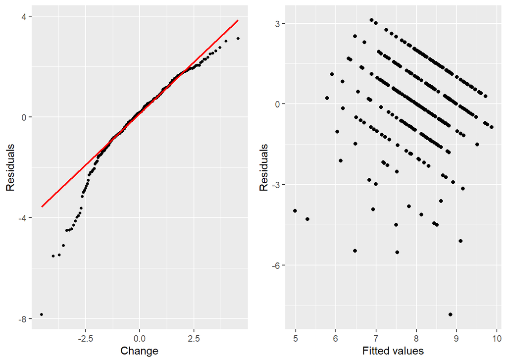

```r
# Residual analysis
p1 <- ggplot(mapping = aes(sample = residuals(model))) +
  stat_qq_point(size = 1, color="black") +
  stat_qq_line(color="red") +
  labs(x="Change", y = "Residuals")
p2 <- ggplot(model, aes(x=fitted(model), y=residuals(model))) +
  geom_point() +
  #geom_point(group=model$model$change, color=model$model$change) +
  labs(x="Fitted values", y="Residuals") +
  theme(legend.position = "top")
grid.arrange(p1, p2, nrow=1)
```

```r
# Kolmogorov-Smirnov test
ksout <- ks.test(residuals(model), "pnorm", mean=0, sd=sd(residuals(model)))
print(ksout)
```

```
##
##  Asymptotic one-sample Kolmogorov-Smirnov test
##
## data:  residuals(model)
## D = 0.082853, p-value = 0.02541
## alternative hypothesis: two-sided
```

## 9 ANOVA analysis

```r
# Run ANOVA analysis to compare program
anova_holis <- aov(holis ~ program, data=dfencr)
summary(anova_holis)
```

```
##              Df Sum Sq Mean Sq F value Pr(>F)
## program       1   0.22  0.2197   0.761  0.384
## Residuals   316  91.26  0.2888
```

```r
anova_social <- aov(social ~ program, data=dfencr)
summary(anova_social)
```

```
##              Df Sum Sq Mean Sq F value Pr(>F)
## program       1   0.24  0.2395   0.431  0.512
## Residuals   316 175.48  0.5553
```

```r
anova_econ <- aov(econ ~ program, data=dfencr)
summary(anova_econ)
```

```
##              Df Sum Sq Mean Sq F value Pr(>F)
## program       1   0.38  0.3752   0.784  0.377
## Residuals   316 151.26  0.4787
```

```r
anova_change <- aov(change ~ program, data=dfencr)
summary(anova_change)
```

```
##              Df Sum Sq Mean Sq F value Pr(>F)
## program       1   16.1  16.062   5.352 0.0213 *
## Residuals   316  948.3   3.001
## ---
## Signif. codes:  0 '***' 0.001 '**' 0.01 '*' 0.05 '.' 0.1 ' ' 1
```

## 10 References

Espinoza, S. C., & Novoa-Muñoz, F. (2018). Ventajas del alfa ordinal respecto al alfa de Cronbach ilustradas con la encuesta AUDIT-OMS. Revista Panamericana de Salud Pública, 42, e65.

Marôco, J. (2024). Factor Analysis of Ordinal Items: Old Questions, Modern Solutions?.

Nye, C. D. (2023). Reviewer resources: Confirmatory factor analysis. Organizational Research Methods, 26(4), 608-628.

Okur-Berberoglu, E. (2020). An ecological intelligence scale intended for adults. World Futures, 76(3), 133-152.

Yves Rosseel (2012). lavaan: An R Package for Structural Equation Modeling. Journal of Statistical Software, 48(2), 1-36. URL http://www.jstatsoft.org/v48/i02/

Zumbo, B. D., Gadermann, A. M., & Zeisser, C. (2007). Ordinal versions of coefficients alpha and theta for Likert rating scales. Journal of modern applied statistical methods, 6, 21-29.